# Mini Data-Analysis Deliverable 1

# Important note

Read Tasks 2 and 3 *fully* before starting to complete either of them. Probably also a good point to grab a coffee to get ready for the fun part!

This project is semi-guided, but meant to be *independent*. For this reason, you will complete tasks 2 and 3 below (under the **START HERE** mark) as if you were writing your own exploratory data analysis report, and this guidance never existed! Feel free to add a brief introduction section to your project, format the document with markdown syntax as you deem appropriate, and structure the analysis as you deem appropriate. Remember, marks will be awarded for completion of the 4 tasks, but 10 points of the whole project are allocated to a reproducible and clean analysis. If you feel lost, you can find a sample data analysis [here](https://www.kaggle.com/headsortails/tidy-titarnic) to have a better idea. However, bear in mind that it is **just an example** and you will not be required to have that level of complexity in your project.

# Task 2: Exploring your dataset (15 points)

If we rewind and go back to the learning objectives, you’ll see that by the end of this deliverable, you should have formulated *4* research questions about your data that you may want to answer during your project. However, it may be handy to do some more exploration on your dataset of choice before creating these questions - by looking at the data, you may get more ideas. **Before you start this task, read all instructions carefully until you reach START HERE under Task 3**.

2.1 Complete *4 out of the following 8 exercises* to dive deeper into your data. All datasets are different and therefore, not all of these tasks may make sense for your data - which is why you should only answer *4*. Use *dplyr* and *ggplot*.

1. Plot the distribution of a numeric variable.
2. Create a new variable based on other variables in your data (only if it makes sense)
3. Investigate how many missing values there are per variable. Can you find a way to plot this?
4. Explore the relationship between 2 variables in a plot.
5. Filter observations in your data according to your own criteria. Think of what you’d like to explore - again, if this was the `titanic` dataset, I may want to narrow my search down to passengers born in a particular year…
6. Use a boxplot to look at the frequency of different observations within a single variable. You can do this for more than one variable if you wish!
7. Make a new tibble with a subset of your data, with variables and observations that you are interested in exploring.
8. Use a density plot to explore any of your variables (that are suitable for this type of plot).

2.2 For each of the 4 exercises that you complete, provide a *brief explanation* of why you chose that exercise in relation to your data (in other words, why does it make sense to do that?), and sufficient comments for a reader to understand your reasoning and code.

See work by each task

# Task 3: Write your research questions (5 points)

So far, you have chosen a dataset and gotten familiar with it through exploring the data. Now it’s time to figure out 4 research questions that you would like to answer with your data! Write the 4 questions and any additional comments at the end of this deliverable. These questions are not necessarily set in stone - TAs will review them and give you feedback; therefore, you may choose to pursue them as they are for the rest of the project, or make modifications!

**Part 2: Exploring the data** Here I will choose 4 of the tasks and complete them below with the data set vancouver_trees. I have chosen tasks 1,4,6,8 due to the nature of my data set. It is a large data set with a lot of categorical variables and a lot of variables that are potentially dependent on one another.

1. Plot the distribution of a numeric variable: I will plot the distribution of tree diameters

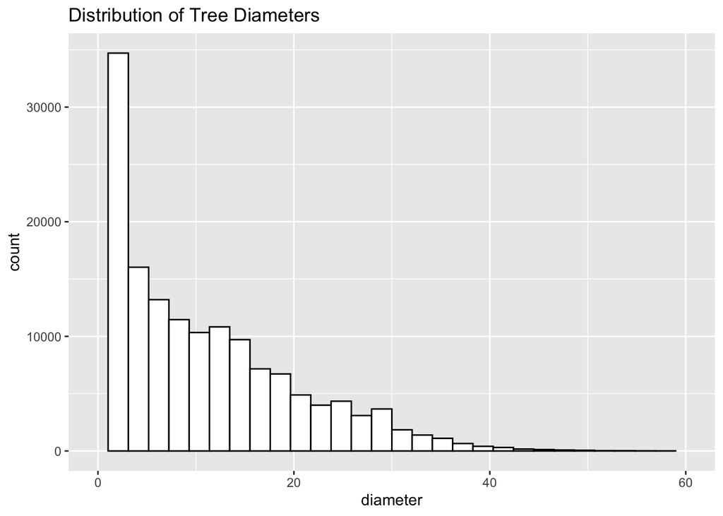

```r
#This is a ggplot showing the distribution of tree diameters in a bar graph to better visualize the main numerical column of the data.
ggplot(vancouver_trees, aes(x=diameter)) + geom_histogram(colour="black", fill="white")+xlim(0, 60)+ggtitle("Distribution of Tree Diameters")
```

4. Explore the relationship between 2 variables in a plot.

```r
#Here I will count how many of the entries  have a root barrier compared with those that do not to better understand what the data looks like.
count(vancouver_trees, root_barrier)
```

```
## # A tibble: 2 × 2
##   root_barrier      n
##   <chr>         <int>
## 1 N            137455
## 2 Y              9156
```

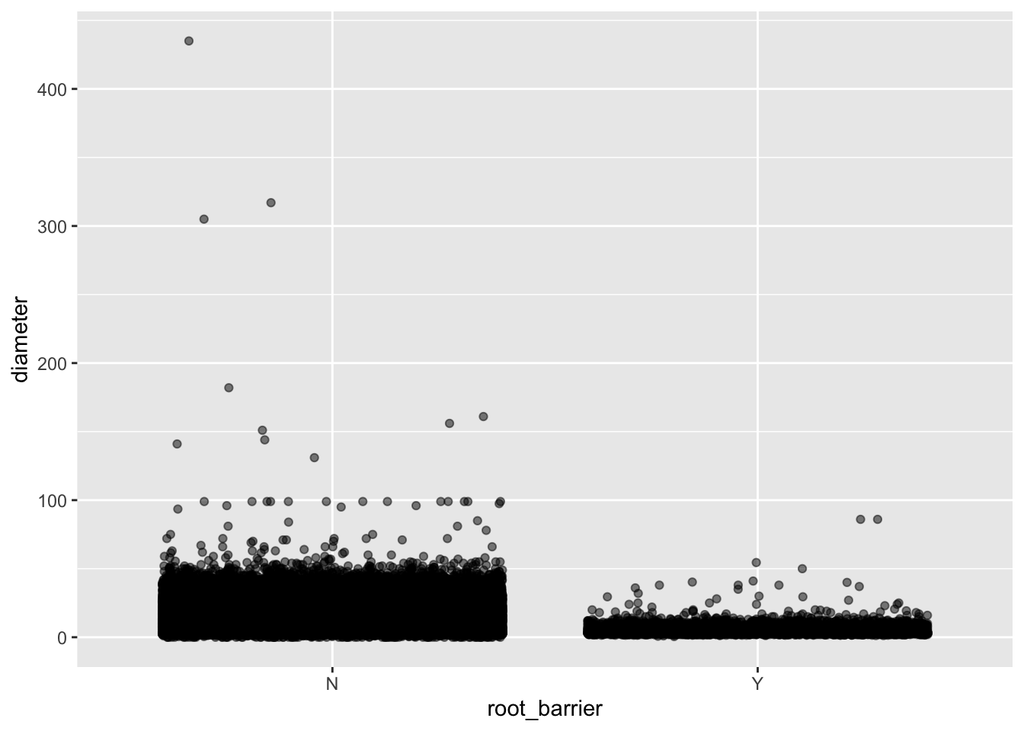

```r
#Here I will plot  a stripplot that shows the relationship between diameter and whether there is a root barrier present or not which is directly related to one of my future questions.
ggplot(vancouver_trees, aes(root_barrier, diameter)) + geom_point(alpha = 0.5, position="jitter")
```

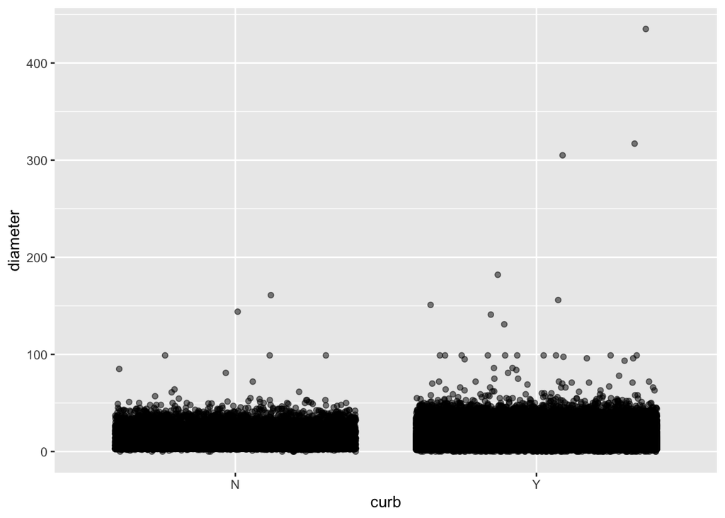

```r
#Here I will plot  a stripplot that shows the relationship between diameter and whether there is a curb present or not.
ggplot(vancouver_trees, aes(curb, diameter)) + geom_point(alpha = 0.5, position="jitter")
```

6. Use a boxplot to look at the frequency of different observations within a single variable. You can do this for more than one variable if you wish!

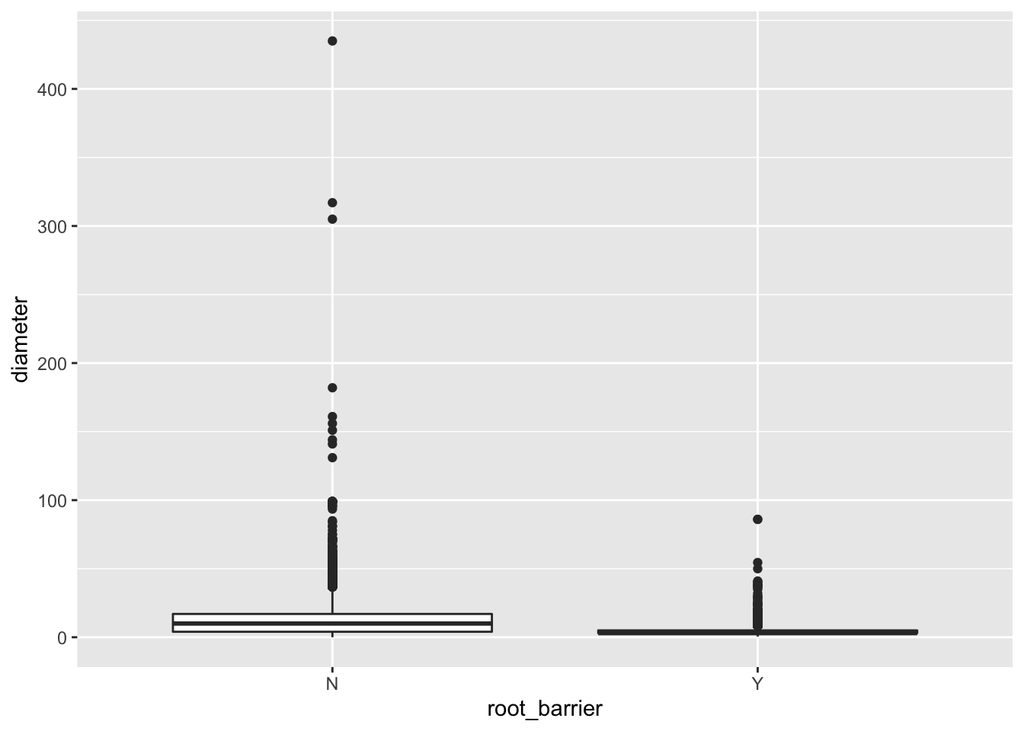

```r
#This makes a boxplot with a comparison of diameter between trees that have and do not have a root barrier.
ggplot(vancouver_trees, aes(root_barrier, diameter)) + geom_boxplot()
```

8. Use a density plot to explore any of your variables (that are suitable for this type of plot).

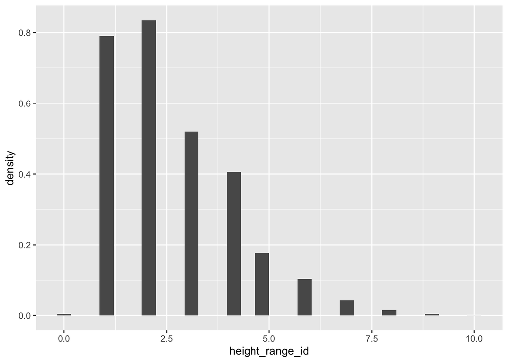

```r
#This makes a histogram showing the density of the height range scales.
ggplot(vancouver_trees, aes(height_range_id)) +geom_histogram(aes(y = ..density..))
```

**Task 3: Write your research questions** 1. Does having a root barrier significantly decrease the average diameter of a tree? 2. Is height correlated to diameter in all tree species? 3. Does having a curb present next to the tree significantly decrease the average diameter of a tree? 4. Does having a curb present next to the tree significantly decrease the average height range of a tree?

# Task 4: Process and summarize your data (13 points)

From Task 2, you should have an idea of the basic structure of your dataset (e.g. number of rows and columns, class types, etc.). Here, we will start investigating your data more in-depth using various data manipulation functions.

### 1.1 (10 points)

Now, for each of your four research questions, choose one task from options 1-4 (summarizing), and one other task from 4-8 (graphing). You should have 2 tasks done for each research question (8 total). Make sure it makes sense to do them! (e.g. don’t use a numerical variables for a task that needs a categorical variable.). Comment on why each task helps (or doesn’t!) answer the corresponding research question.

Ensure that the output of each operation is printed!

**Task 1.1**

Question 1. Does having a root barrier significantly decrease the average diameter of a tree? These tasks were each helpful to visualize the data. The boxplot is difficult to interpret as the boxes are so short/narrow. A statistical test would be more decisive for conclusions. The distribution of diameters is interesting to look at, but it does not answer the question and the same with the density plot. The boxplot would be the most effective for answering the questions, but again, it is difficult to interpret.

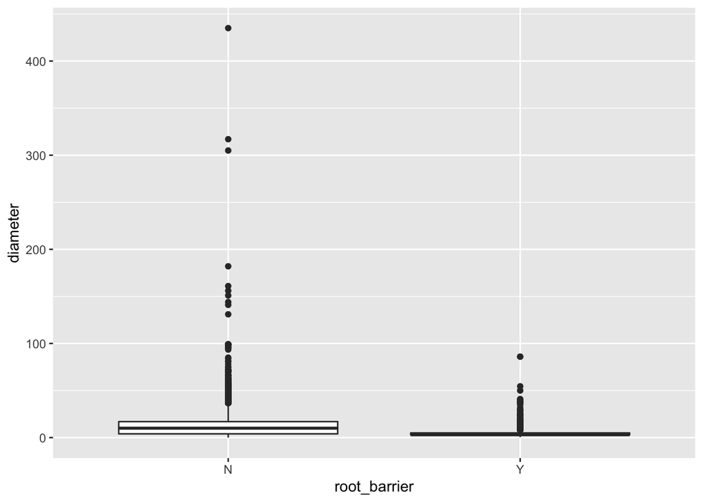

```r
# Make a boxplot relating the two variables to look at their relationship
ggplot(vancouver_trees, aes(root_barrier, diameter)) + geom_boxplot()
```

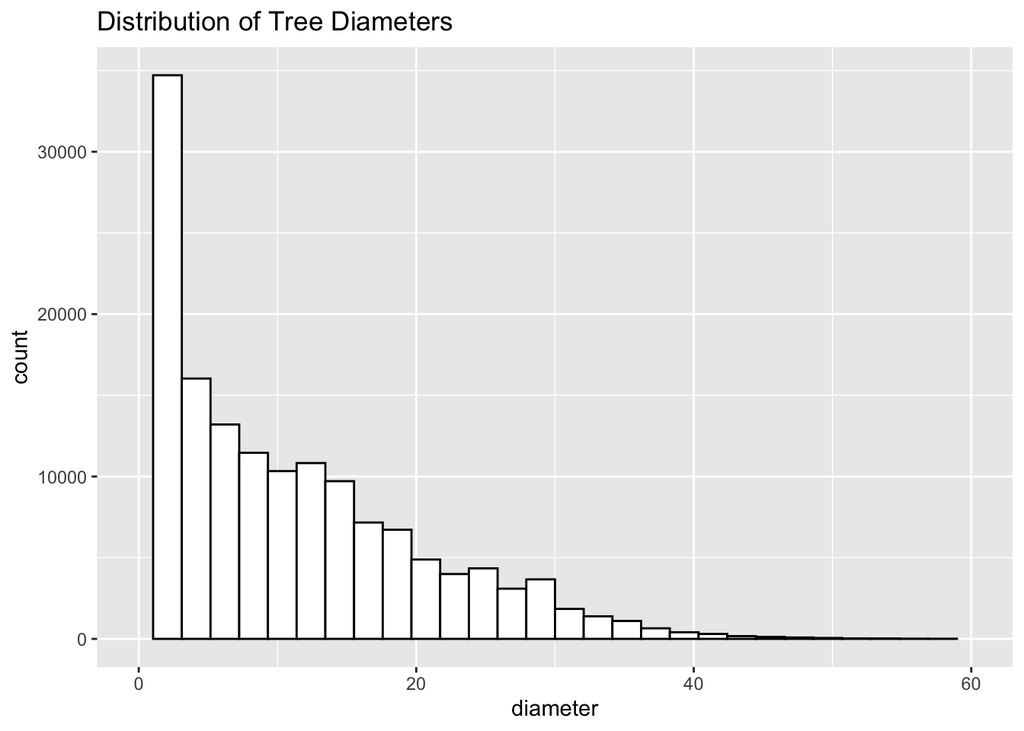

```r
#show the distribution of diameters in a histogram
ggplot(vancouver_trees, aes(x=diameter)) + geom_histogram(colour="black", fill="white")+xlim(0, 60)+ggtitle("Distribution of Tree Diameters")
```

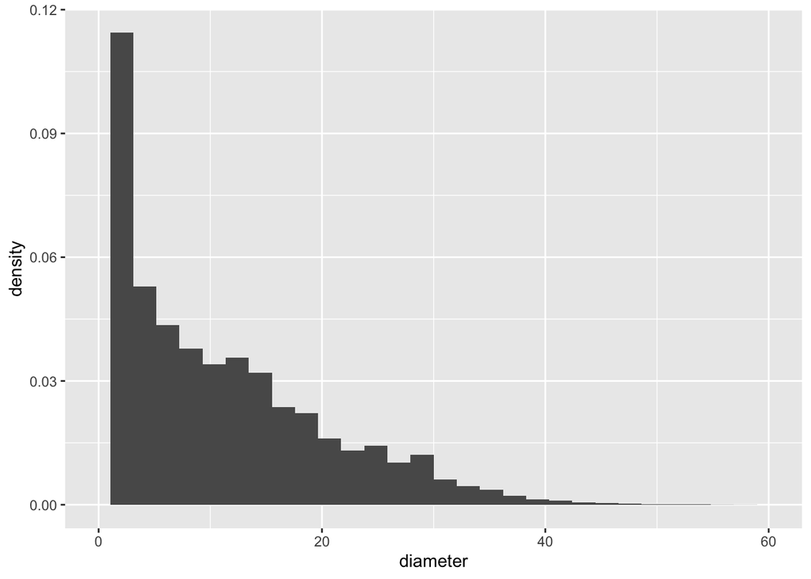

```r
#This will make a density plot of diameters
ggplot(vancouver_trees, aes(diameter)) +geom_histogram(aes(y = ..density..))+xlim(0,60)
```

Question 2. Is height correlated to diameter in all tree species? The first plot is a boxplot by height range id showing diameters. It is incredibly helpful for the question as it shows that as the height increases the diameter does as well. Then, I filtered the data to only include trees that are not on a curb and remade the same boxplot to see if this had a visible effect. The data looks fairly similar and statistical tests would be needed to determine significance.

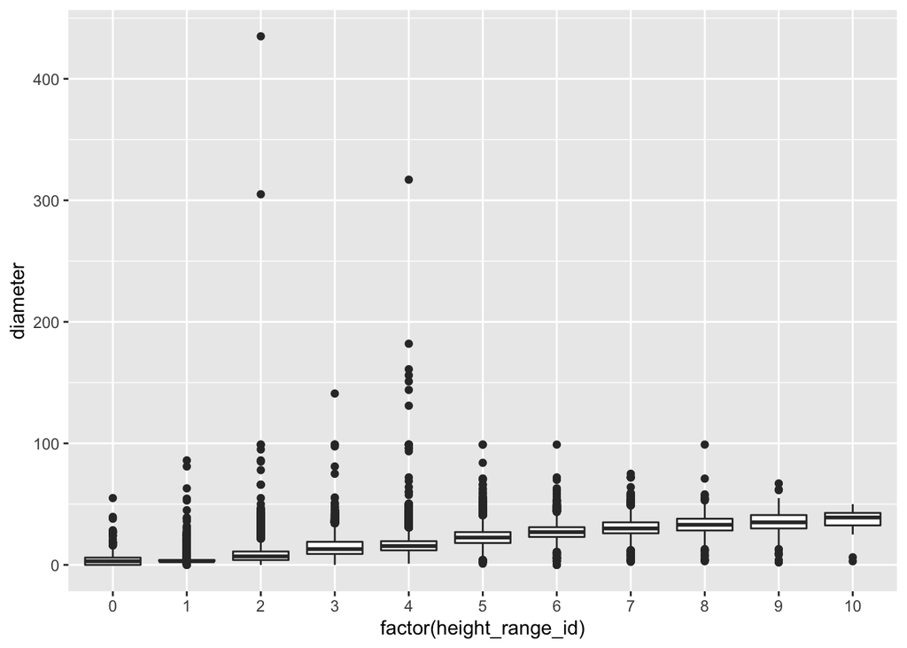

```r
# Make a boxplot relating the two variables to look at their relationship
ggplot(vancouver_trees, aes(factor(height_range_id), diameter)) + geom_boxplot()
```

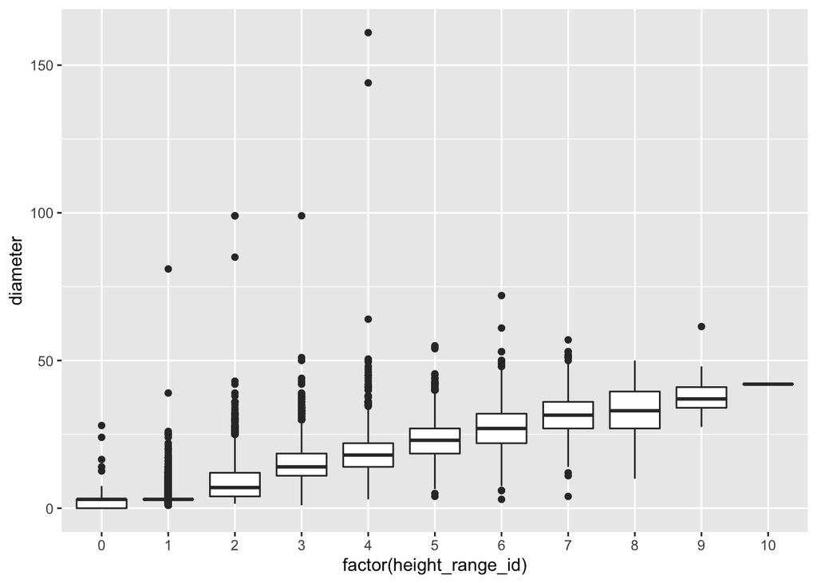

```r
# Filter the data to make a set of only trees without a curb
van_trees_noCurb=vancouver_trees %>% filter(curb == "N")
#now this will remake the same boxplot but with the filtered data.
ggplot(van_trees_noCurb, aes(factor(height_range_id), diameter)) + geom_boxplot()
```

Question 3. Does having a curb present next to the tree significantly decrease the average diameter of a tree? This once again is difficult to tell the answer to the question due to the narrow span of the boxplots. Statistical tests are needed to make conclusions. The filtering changes the graph a little, but not a huge amount.

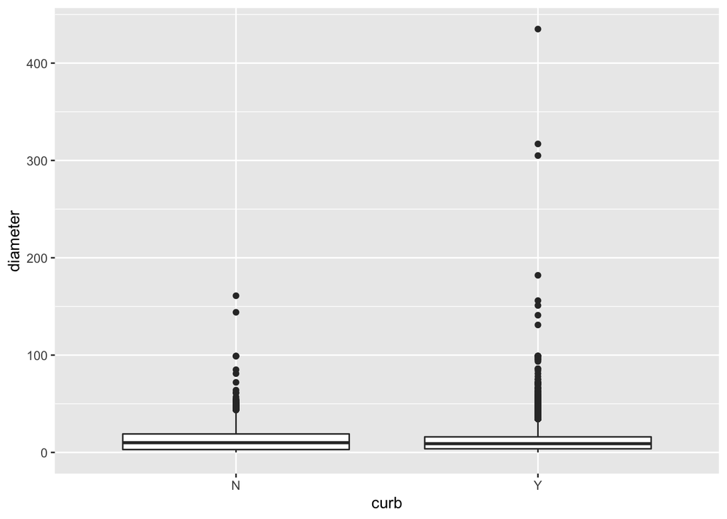

```r
#This will make a boxplot showing the presence of a curb as it relates to diameter
ggplot(vancouver_trees, aes(curb, diameter)) + geom_boxplot()
```

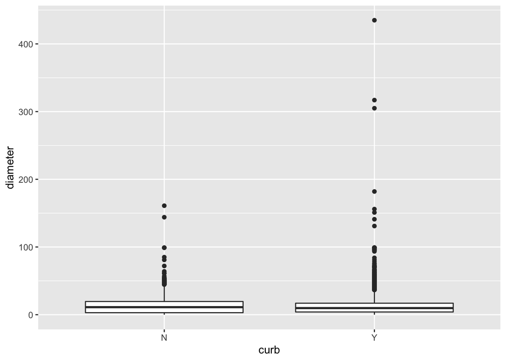

```r
#this will remove the trees that have a root barrier from the data and then replot the boxplot with the new data set.
van_trees_noBar=vancouver_trees %>% filter(root_barrier == "N")
ggplot(van_trees_noBar, aes(curb, diameter)) + geom_boxplot()
```

Question 4. Does having a curb present next to the tree significantly decrease the average height range of a tree? The boxplot is quite definitive that there is no difference between the average height range of trees with and without curbs.

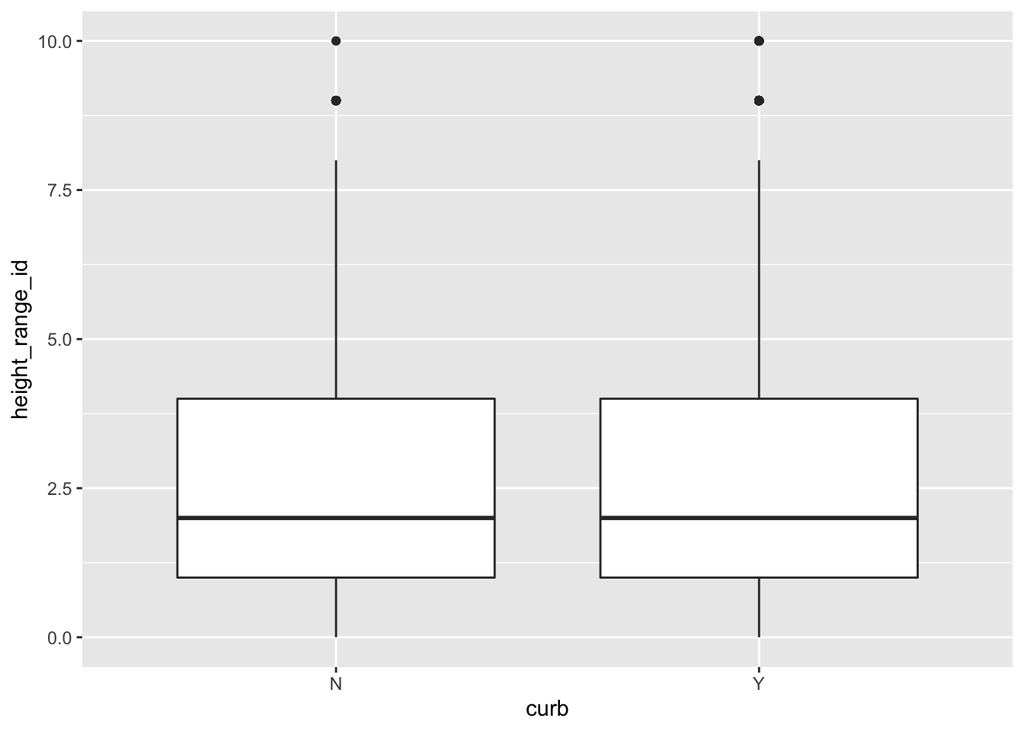

```r
#this will make a boxplot with the relation between curb presence and height range.
ggplot(vancouver_trees, aes(curb, height_range_id)) + geom_boxplot()
```

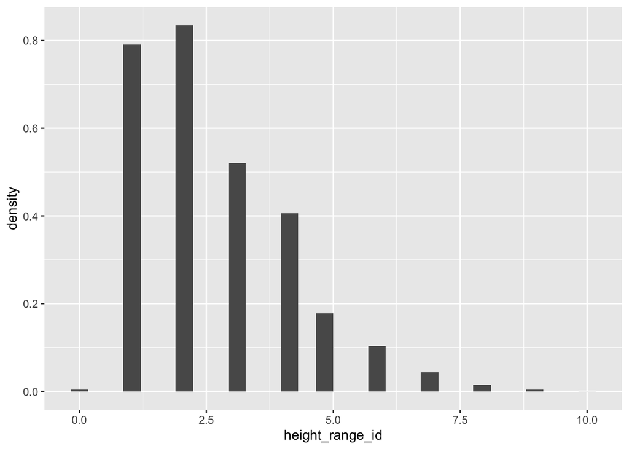

```r
#This will make a density plot of height range
ggplot(vancouver_trees, aes(height_range_id)) +geom_histogram(aes(y = ..density..))
```

**Summarizing:**

1. Compute the *range*, *mean*, and *two other summary statistics* of **one numerical variable** across the groups of **one categorical variable** from your data. This is interesting for question 1 as it pertains to the diameters and gives a better picture of the distribution of values

```r
#here I will calculate the maximum diameter and minimum diameter for each height class and then calculate the range.
maxDbh=aggregate(diameter~height_range_id,data=vancouver_trees,max)
minDbh=aggregate(diameter~height_range_id,data=vancouver_trees,min)
rangeDbh=maxDbh-minDbh
rangeDbh
```

```
##    height_range_id diameter
## 1                0     55.0
## 2                0     86.0
## 3                0    435.0
## 4                0    141.0
## 5                0    316.0
## 6                0     98.0
## 7                0     99.0
## 8                0     72.5
## 9                0     96.0
## 10               0     65.0
## 11               0     47.0
```

```r
#this is the mean diameter of trees in each height class
aggregate(diameter~height_range_id,data=vancouver_trees,mean)
```

```
##    height_range_id  diameter
## 1                0  5.407009
## 2                1  3.917364
## 3                2  8.376343
## 4                3 14.641436
## 5                4 16.562707
## 6                5 22.824920
## 7                6 27.268643
## 8                7 30.775249
## 9                8 33.250818
## 10               9 34.789409
## 11              10 34.145833
```

```r
#this is the median diameter of trees in each height class
aggregate(diameter~height_range_id,data=vancouver_trees,median)
```

```
##    height_range_id diameter
## 1                0      3.0
## 2                1      3.0
## 3                2      7.0
## 4                3     13.0
## 5                4     15.5
## 6                5     22.5
## 7                6     27.0
## 8                7     30.0
## 9                8     33.0
## 10               9     35.0
## 11              10     39.0
```

```r
#this is the standard deviation of the diameter of trees in each height class
aggregate(diameter~height_range_id,data=vancouver_trees,sd)
```

```
##    height_range_id  diameter
## 1                0  8.110500
## 2                1  2.279372
## 3                2  5.987273
## 4                3  7.601208
## 5                4  7.034131
## 6                5  7.163670
## 7                6  7.111473
## 8                7  7.458009
## 9                8  8.273350
## 10               9  9.691061
## 11              10 15.274927
```

2. Compute the number of observations for at least one of your categorical variables. Do not use the function `table()`! This is interesting for questions 3 and 4 as they both pertain to curbs.

```r
#This will count the number of observations for yes and no to a curb
(summary_data <- vancouver_trees %>%
    group_by(curb) %>%
    summarise(Count = n())  )
```

```
## # A tibble: 2 × 2
##   curb   Count
##   <chr>  <int>
## 1 N      12804
## 2 Y     133807
```

3. Create a categorical variable with 3 or more groups from an existing numerical variable. You can use this new variable in the other tasks! *An example: age in years into “child, teen, adult, senior”.* This could be interesting to include in the question numbers 1,2, and 3 as they pertain to diameter. It is common to group diameter into classes that represent the major life stages of a tree.

```r
#Here I create a new column called DiamRanges that represent the tree diameters of three groups that define the life stage that the trees fit within.
vancouver_trees_new <- within(vancouver_trees, {
  DiamRanges <- NA # need to initialize variable
  DiamRanges[diameter < 100] <- "Sapling"
  DiamRanges[diameter >= 100 & diameter < 300] <- "Medium_growth"
  DiamRanges[diameter >= 300] <- "Old_growth"
   } )
vancouver_trees_new
```

```
## # A tibble: 146,611 × 21
##    tree_id civic_number std_st…¹ genus…² speci…³ culti…⁴ commo…⁵ assig…⁶ root_…⁷
##      <dbl>        <dbl> <chr>    <chr>   <chr>   <chr>   <chr>   <chr>   <chr>
##  1  149556          494 W 58TH … ULMUS   AMERIC… BRANDON BRANDO… N       N
##  2  149563          450 W 58TH … ZELKOVA SERRATA <NA>    JAPANE… N       N
##  3  149579         4994 WINDSOR… STYRAX  JAPONI… <NA>    JAPANE… N       N
##  4  149590          858 E 39TH … FRAXIN… AMERIC… AUTUMN… AUTUMN… Y       N
##  5  149604         5032 WINDSOR… ACER    CAMPES… <NA>    HEDGE … N       N
##  6  149616          585 W 61ST … PYRUS   CALLER… CHANTI… CHANTI… N       N
##  7  149617         4909 SHERBRO… ACER    PLATAN… COLUMN… COLUMN… N       N
##  8  149618         4925 SHERBRO… ACER    PLATAN… COLUMN… COLUMN… N       N
##  9  149619         4969 SHERBRO… ACER    PLATAN… COLUMN… COLUMN… N       N
## 10  149625          720 E 39TH … FRAXIN… AMERIC… AUTUMN… AUTUMN… N       N
## # … with 146,601 more rows, 12 more variables: plant_area <chr>,
## #   on_street_block <dbl>, on_street <chr>, neighbourhood_name <chr>,
## #   street_side_name <chr>, height_range_id <dbl>, diameter <dbl>, curb <chr>,
## #   date_planted <date>, longitude <dbl>, latitude <dbl>, DiamRanges <chr>, and
## #   abbreviated variable names ¹std_street, ²genus_name, ³species_name,
## #   ⁴cultivar_name, ⁵common_name, ⁶assigned, ⁷root_barrier
```

4. Based on two categorical variables, calculate two summary statistics of your choosing. This is interesting in general. It is specific to question 3 and 4 which pertain to curbs.

```r
#This gives the rows as curb and the columns as root_barrier. The four summary statistics provided are the number of each combination.
table(vancouver_trees$curb, vancouver_trees$root_barrier)
```

```
##
##          N      Y
##   N  12080    724
##   Y 125375   8432
```

**Graphing:**

5. Create a graph out of summarized variables that has at least two geom layers. This question is going off of the previous one. It produces a graph that pertains to curb and root barrier status.

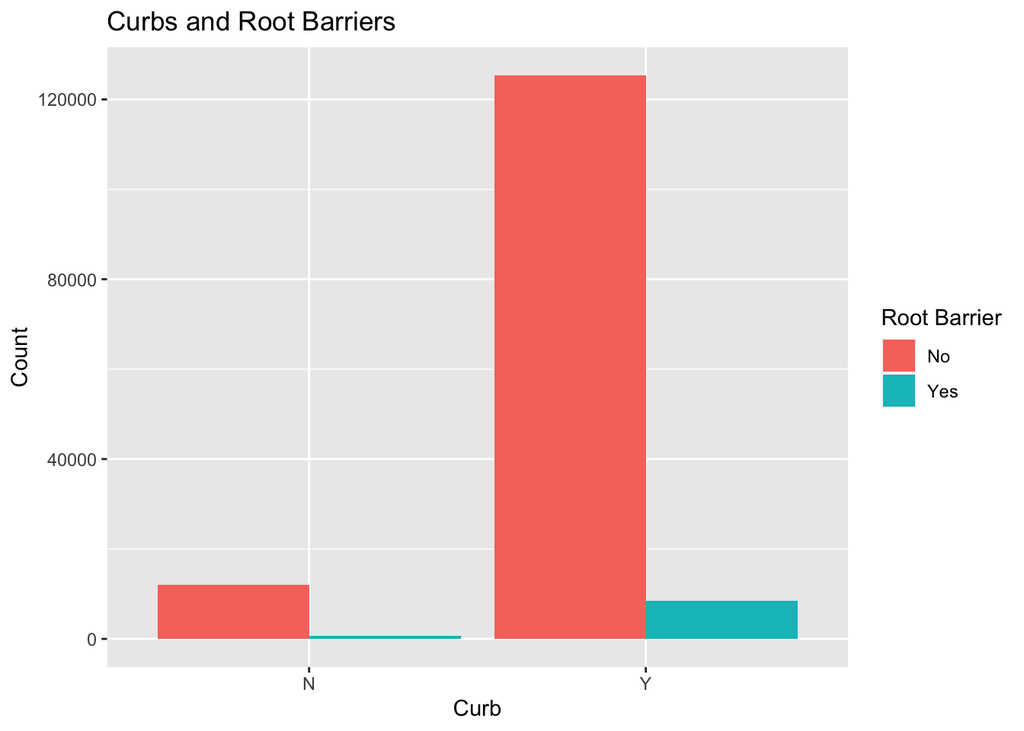

```r
#This is a bar chart in ggplot with many layers to specify all of the details and names.
ggplot(vancouver_trees, aes(curb, ..count..)) + geom_bar(aes(fill = root_barrier), position = "dodge")+xlab("Curb")+ggtitle("Curbs and Root Barriers")+ylab("Count")+scale_fill_discrete(name = "Root Barrier", labels = c("No", "Yes"))
```

6. Create a graph of your choosing, make one of the axes logarithmic, and format the axes labels so that they are “pretty” or easier to read.

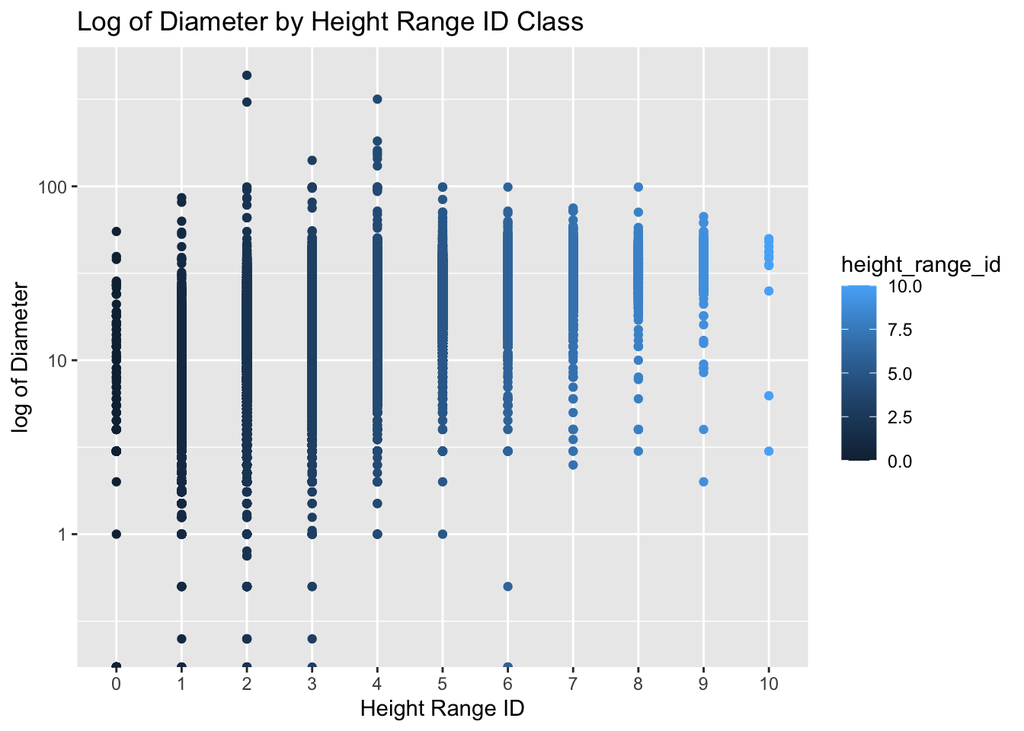

```r
#this is a graph of the log of diameter by height range id which is interesting for question 2.
ggplot(vancouver_trees, aes(x = factor(height_range_id), y = diameter, color=height_range_id)) + xlab("Height Range ID")+ylab("log of Diameter")+geom_point()+ scale_y_continuous(trans='log10')+scale_fill_discrete(name = "Height Range ID")+ggtitle("Log of Diameter by Height Range ID Class")
```

7. Make a graph where it makes sense to customize the alpha transparency.

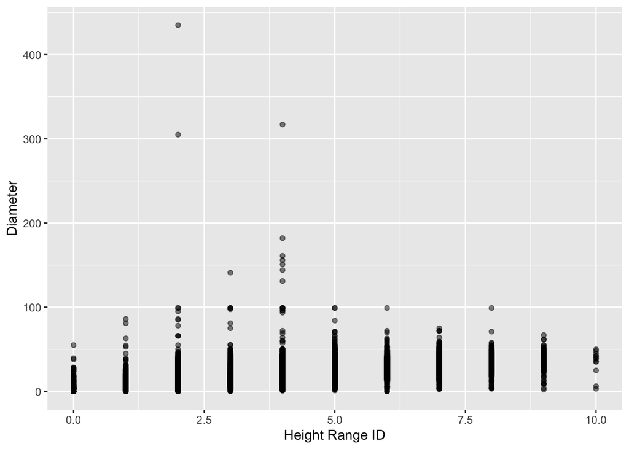

```r
#adding some transparency to the graph allows a clearer image of where each point falls.
ggplot(vancouver_trees, aes(x = height_range_id, y = diameter)) + xlab("Height Range ID")+ylab("Diameter")+geom_point(alpha = 0.5)
```

8. Create 3 histograms out of summarized variables, with each histogram having different sized bins. Pick the “best” one and explain why it is the best. Interesting for questions 1 and 4 due to the subject being height class.

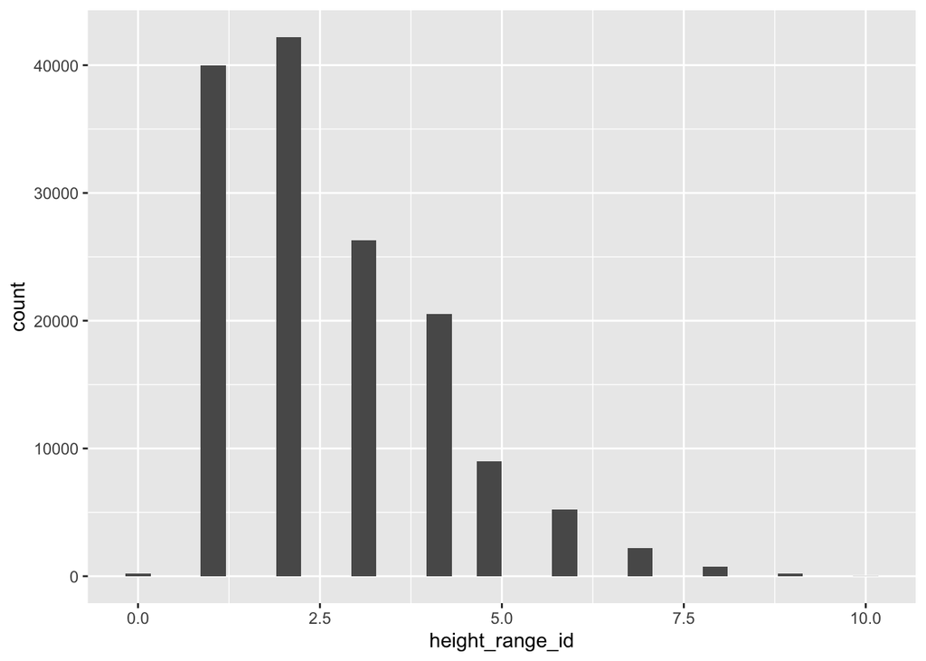

```r
#The default is 30 bins
ggplot(vancouver_trees, aes(height_range_id)) +geom_histogram(aes(y = ..count..))
```